# Prosper Loan Analytics

## by (Satyam Chauhan)

## Investigation Overview

> Explorative analysis gave out bunch of key insights. I would like like to use visualizations that show top loan type, top professions (this could be used by prosper for targeted loan offering or selling that information to businesses for targeted ad) Thereafter I would like to visualize borrower apr vs income band to see how the interest rates vary based on income band

> Finally, I would conclude with two multivariate plots

> 1st visualization will show the relationship between lender's yeild, borrower's rate and prosper rating and the 2nd visualization will show the loan amount requeted by various income bands and how it fares againts interest rates

## Dataset Overview

> This data set contains 113,937 loans with 81 variables on each loan, including loan amount, borrower rate (or interest rate), current loan status, borrower income, and many others. The idea to analyze various features and generate informative visuals. It would be interesting to see how certain feature influence borrowers APR or what's the most popular purpose for loan etc.

## Visualization 1

This graph visualizes different loan types with their completion and default rate

Debt consolidation is the top loan type followed business and home improvement

This insight can be used for tarrgeted ad and laon offers to the customers

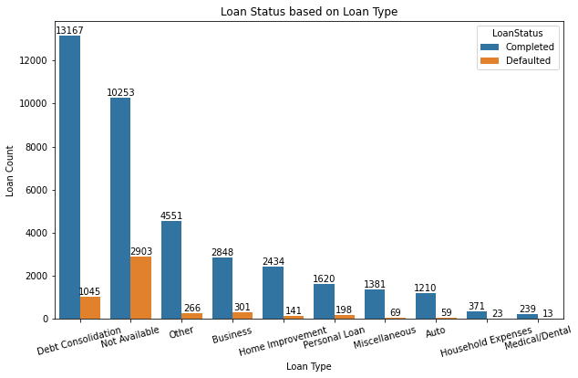

## Visualization 2

The idea is to idenitfy professions of the customers see their default and completion rate

Prosper's top customers are computer programmers, Analyst, and Admin Assistant

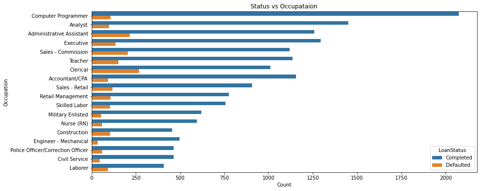

## Visualization 3

This is a distribution of income based on income category against borrower's apr

Income bands with very high and no income (students) receive favorable interest rates

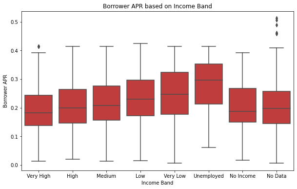

## Visualization 4

The obvious relation between Borrower's APR, Lender's yeild and and prosper score rating.

The borrower's interest and lenders yeild increases with deteriorating rating since it increases the investor's risk

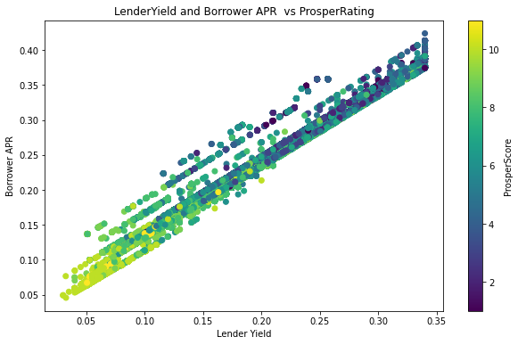

## Visualization 5

Here, we are trying to see a pattern for income groups, their lending needs and what kind of borrower's rate they are abel to receive

We can see loan amount granted increases with income level

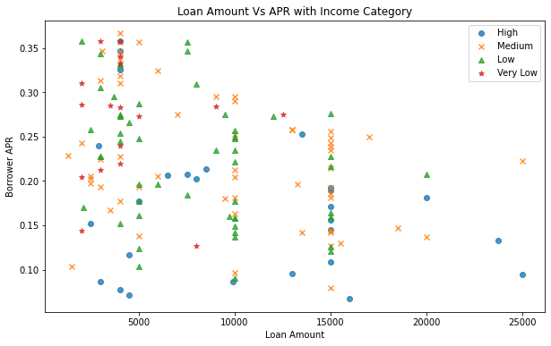